# 2-Cross-Slice-Comparison

*Nabila Rahman*

*2025-07-21*

```r
# Core analysis packages
library(Seurat)
library(SeuratObject)
library(ggplot2)
library(dplyr)
library(tidyr)
library(data.table)
library(patchwork)
library(tidyverse)

# Spatial transcriptomics specific
library(spatstat)
library(Matrix)
library(rjson)
library(cowplot)
library(RColorBrewer)
library(viridis)
library(DT)
library(hdf5r)

# Single cell integration
library(harmony)
library(clustree)
library(scran)
library(scater)
library(cluster)

# Drug discovery and pathway analysis
library(clusterProfiler)
library(org.Hs.eg.db)
library(ReactomePA)
library(GSVA)
library(msigdbr)
library(enrichplot)

# Cell-cell communication
library(CellChat)
library(nichenetr)

# Statistical analysis
library(ComplexHeatmap)
library(circlize)
library(corrplot)
library(survival)
library(survminer)

# Biomarker discovery
library(randomForest)
library(caret)
library(pROC)
library(ROCR)

# Set theme for consistent plotting
theme_set(
  theme_bw() + theme(
    plot.title = element_text(
      size = 14
      , face = "bold"
    )
    , axis.title = element_text(size = 12)
    , axis.text = element_text(size = 10)
    , legend.text = element_text(size = 10)
  )
)

# Set random seed for reproducibility
set.seed(42)

# Create directory structure
workDir <- "G:/SpatialOmics/Tx_Drug_Discovery"

setwd(workDir)
```

```r
scrna_ref <- readRDS(file.path(workDir, "/data/processed", "hcc_scrna_reference.RDS"))

spatial_list <- readRDS( file.path(workDir, "data/processed", "spatial_samples_sct_dimr.RDS" ) )
```

# 1 A Summary of current Cross Slice Comparison Methods

[output not shown]

| **Rank** | **Method** | **Cross-Tech Score** | **Supported Technologies** | **Key Strength** | **Limitations** |
| --- | --- | --- | --- | --- | --- |
| **1** | **CAST** | **10/10** | Visium, STARmap, MERFISH, RIBOmap, Slide-seq, Stereo-seq | Single-cell resolution across all platforms | Very new (2024), limited validation |
| **2** | **STalign** | **9/10** | Visium, MERFISH, Slide-seq, STARmap | Diffeomorphic mapping handles coordinate differences | Complex parameter tuning |
| **3** | **SANTO** | **8.5/10** | 10x Xenium, Visium, subcellular platforms | Coarse-to-fine handles resolution differences | Requires overlapping regions |
| **4** | **STAligner** | **8/10** | Multiple platforms via graph attention | Scalable across technologies | Limited to similar gene panels |
| **5** | **SpatialGlue** | **7.5/10** | Multi-modal spatial platforms | Handles different data modalities | Requires paired multi-omics data |
| **6** | **DeepST** | **6/10** | Limited cross-platform capability | Graph networks adapt to different inputs | Not specifically designed for cross-tech |
| **7** | **SPIRAL** | **5.5/10** | Some cross-platform support | Optimal transport framework | Poor performance on distant platforms |
| **8** | **SPACEL** | **5/10** | Primarily Visium-focused | Good 3D reconstruction | Limited cross-technology validation |
| **9** | **PASTE** | **4/10** | Similar technologies only (Visium-Visium) | Excellent for same platform | Fails with different coordinate systems |
| **10** | **PRECAST** | **4/10** | Limited cross-platform | Bayesian framework flexible | Not designed for technology differences |
| **11** | **GPSA** | **3/10** | Minimal cross-technology support | Probabilistic approach | Poor scalability across platforms |
| **12** | **Seurat Integration** | **2/10** | Same format data only | Familiar workflow | No cross-technology awareness |

### 1.0.1 Key Findings:

*Rankings based on comprehensive benchmarks from Genome Biology 2024, Nature Methods 2022-2024, and spatial omics literature.*

*Best performance indicators marked with asterisk (*)

# 2 Seurat Integration (CCA/RPCA)

Aligns image. Remove technical effect

Finds “anchor” cells/spots that are similar across different datasets. Then Uses the anchors to align gene expression across datasets

*Why do we need it?*

**Click for Details**

Without integration same cell types look different across slices due to:

Technical batch effects - Different sequencing depths - Processing variations

With integration Same cell types cluster together regardless of which slice they came from.

Simple analogy: FindIntegrationAnchors = “Find matching landmarks across different maps” IntegrateData = “Use landmarks to align all maps into one coherent map”

```r
if (!file.exists(file.path(workDir, "/data/processed", "spatial.Seurat.integrated.preDim.RDS"))) {
# Integration using Seurat
# Step 1: Select integration features
## Selects highly variable genes that are consistently variable across multiple datasets
## Reduces Noise: Filters out genes that are not informative for integration

features <- SelectIntegrationFeatures(
  object.list = spatial_list
  , nfeatures = 3000
)

# Step 2:ReNormalise on spatially informative genes.
spatial_list <- lapply(
  spatial_list
  , function(obj) {
    SCTransform(
      obj
      , assay = "Spatial"
      , method = "poisson"
      , variable.features.n = 3000
      , verbose = FALSE
      , return.only.var.genes = FALSE  # Critical parameter
    )
  }
)

# Step 3: Re-select features after SCTransform
features <- SelectIntegrationFeatures(
  object.list = spatial_list
  , nfeatures = 2000
)

# Step 4: Prepare SCT integration
spatial_list <- PrepSCTIntegration(
  object.list = spatial_list
  , anchor.features = features
)

# Step 5: integration anchors
spatial.anchors <- FindIntegrationAnchors(
  object.list = spatial_list
  , normalization.method = "SCT"
  , anchor.features = features
  , dims = 1:30
)

# Step 6:Integrate data
spatial.integrated <- IntegrateData(
  anchorset = spatial.anchors
  , normalization.method = "SCT"
  , dims = 1:30
)

# Switch to integrated assay for downstream analysis
DefaultAssay(spatial.integrated) <- "integrated"

  saveRDS(spatial.integrated, file.path(workDir, "/data/processed", "spatial.Seurat.integrated.preDim.RDS"))
} else  {
  spatial.integrated <- readRDS(file.path(workDir, "/data/processed", "spatial.Seurat.integrated.preDim.RDS"))
}
```

## 2.1 Response and QC visualizations

```r
if (!file.exists(file.path(workDir, "/data/processed", "spatial.Seurat.integrated.RDS"))) {

  # Scale integrated data
  spatial.integrated <- ScaleData(
    spatial.integrated
    , verbose = FALSE
  )

  # Run PCA
  spatial.integrated <- RunPCA(
    spatial.integrated
    , npcs = 50
    , verbose = FALSE
  )

  # Determine optimal number of PCs
  ElbowPlot(
    spatial.integrated
    , ndims = 50
  )

  # Run UMAP
  spatial.integrated <- RunUMAP(
    spatial.integrated
    , reduction = "pca"
    , dims = 1:15
    , verbose = FALSE
  )

  # Find neighbors and clusters
  spatial.integrated <- FindNeighbors(
    spatial.integrated
    , reduction = "pca"
    , dims = 1:15
    , verbose = FALSE
  )

  spatial.integrated <- FindClusters(
    spatial.integrated
    , resolution = c(0.1, 0.3, 0.5, 0.8, 1.0)
    , verbose = FALSE
  )

  saveRDS(spatial.integrated, file.path(workDir, "/data/processed", "spatial.Seurat.integrated.RDS"))
} else  {
  spatial.integrated <- readRDS(file.path(workDir, "/data/processed", "spatial.Seurat.integrated.RDS"))
}
```

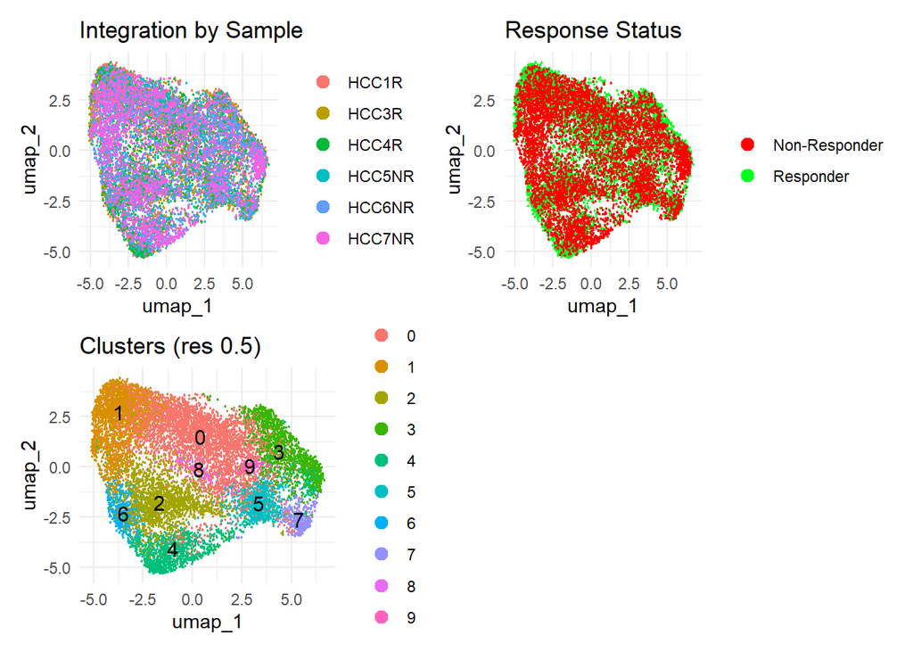

```r
spatial.integrated$response <- ifelse(grepl("NR", spatial.integrated$sample_id), "Non-Responder", "Responder")

# UMAP visualization by sample
p1 <- DimPlot(
  spatial.integrated
  , reduction = "umap"
  , group.by = "sample_id"
  , label = FALSE
) +
  ggtitle("Integration by Sample") +
  theme_minimal()

# UMAP visualization by response
p2 <- DimPlot(
  spatial.integrated
  , reduction = "umap"
  , group.by = "response"
  , cols = c("Responder" = "#00ff20", "Non-Responder" = "#ff0000")
  , label = FALSE
) +
  ggtitle("Response Status") +
  theme_minimal()

p3 <- DimPlot(
  spatial.integrated
  , reduction = "umap"
  , group.by = "integrated_snn_res.0.5"
  , label = TRUE
  , label.size = 4
) +
  ggtitle("Clusters (res 0.5)") +
  theme_minimal()


# UMAP visualization by clusters
p3 <- DimPlot(
  spatial.integrated
  , reduction = "umap"
  , group.by = "integrated_snn_res.0.5"
  , label = TRUE
  , label.size = 4
) +
  ggtitle("Clusters (res 0.5)") +
  theme_minimal()

(p1 | p2) / (p3 | plot_spacer())
```

## 2.2 Spatial Visualisation of clusters

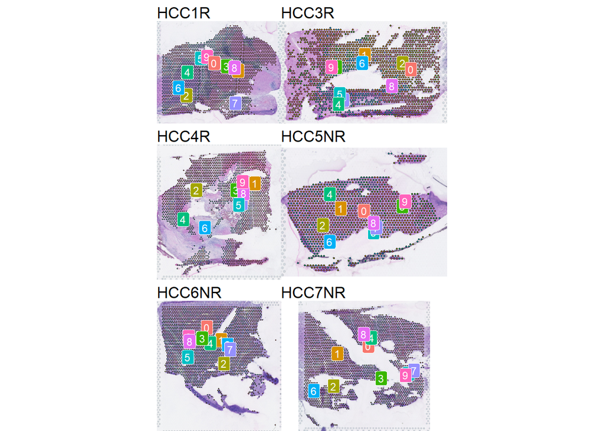

```r
# Set active identity to clusters
Idents(spatial.integrated) <- "integrated_snn_res.0.5"
spatial.integrated$orig.ident <-spatial.integrated$sample_id

# Spatial plots for each sample showing clusters
sample_names <- unique(spatial.integrated$sample_id)

# Combined spatial plot showing clusters across all samples
spatial_clusters <- SpatialDimPlot(
  spatial.integrated
  , label = TRUE
  , label.size = 3
  , stroke = 0
  , ncol = 2
) &
  theme_void() &
  theme(legend.position = "none")

spatial_clusters
```

## 2.3 Integration QC

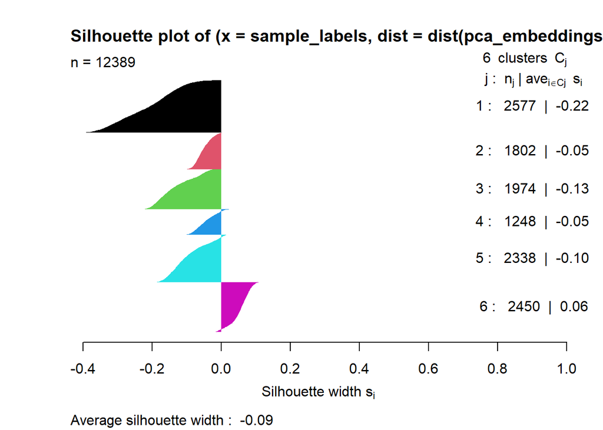

Figure 2.1: Most silhouette scores are negative for Samples 1-5, meaning spots have high cross sample similarity than within sample similar. I.e. no batch effect. Lower is better

```r
# Check integration quality with key metrics
integration_metrics <- list()

# Calculate silhouette scores for integration (using optimal PCs)
pca_embeddings <- Embeddings(spatial.integrated, reduction = "pca")[, 1:15]
sample_labels <- as.numeric(as.factor(spatial.integrated$orig.ident))
sil_scores <- silhouette(sample_labels, dist(pca_embeddings))
integration_metrics$silhouette_score <- mean(sil_scores[, 3])

# Plot silhouette analysis
plot(sil_scores, col = 1:length(unique(sample_labels)), border = NA)
```

## 2.4 Marker Gene Identification

```r
# Switch to SCT assay for DE analysis (if SCTransform was used)
DefaultAssay(spatial.integrated) <- "SCT"
Idents(spatial.integrated) <- "response"

# Because there are a different noice model per sample, we need to normalise this across samples
spatial.integrated.dctf <- PrepSCTFindMarkers(spatial.integrated)

library(future)
options(future.globals.maxSize = 16000 * 1024^2)  # 8GB limit
plan("sequential")

response_degs  <- FindMarkers(
  spatial.integrated.dctf
  , ident.1 = "Responder"
  , ident.2 = "Non-Responder"
  , logfc.threshold = 0.1
  , min.pct = 0.25
  , test.use = "wilcox"
  , verbose = FALSE
)

# Display
# Add gene names and significance
response_degs$gene <- rownames(response_degs)
response_degs$significance <- ifelse(response_degs$p_val_adj < 0.05, "Significant", "Not Significant")
response_degs$direction <- ifelse(response_degs$avg_log2FC > 0, "Higher_in_Responders", "Higher_in_Non_Responders")

response_degs %>%
  filter(avg_log2FC > 0, p_val_adj < 0.05) %>%
  arrange(desc(avg_log2FC)) %>%
  head(10) %>%
  dplyr::select(-direction) %>%
  knitr::kable(caption="Top 10 Responder specific genes"
  )
```

Table 2.1: Top 10 Responder specific genes

|  | p_val | avg_log2FC | pct.1 | pct.2 | p_val_adj | gene | significance |
| --- | --- | --- | --- | --- | --- | --- | --- |
| RPS4Y1 | 0 | 11.470636 | 0.313 | 0.000 | 0 | RPS4Y1 | Significant |
| MT1H | 0 | 9.792197 | 0.322 | 0.001 | 0 | MT1H | Significant |
| CCL19 | 0 | 9.004973 | 0.397 | 0.002 | 0 | CCL19 | Significant |
| MT1G | 0 | 8.684378 | 0.599 | 0.010 | 0 | MT1G | Significant |
| MT1M | 0 | 8.525536 | 0.451 | 0.002 | 0 | MT1M | Significant |
| NQO1 | 0 | 7.897558 | 0.635 | 0.007 | 0 | NQO1 | Significant |
| IGHG4 | 0 | 7.578065 | 0.615 | 0.020 | 0 | IGHG4 | Significant |
| CPLX2 | 0 | 7.221432 | 0.252 | 0.002 | 0 | CPLX2 | Significant |
| SAA2 | 0 | 7.158493 | 0.606 | 0.046 | 0 | SAA2 | Significant |
| SAA1 | 0 | 6.845408 | 0.890 | 0.101 | 0 | SAA1 | Significant |

```r
response_degs %>%
  filter(avg_log2FC < 0, p_val_adj < 0.05) %>%
  arrange(desc(avg_log2FC)) %>%
  head(10) %>%
  dplyr::select(-direction) %>%
  knitr::kable(caption="Top 10 Non-Responder specific genes"
  )
```

Table 2.1: Top 10 Non-Responder specific genes

|  | p_val | avg_log2FC | pct.1 | pct.2 | p_val_adj | gene | significance |
| --- | --- | --- | --- | --- | --- | --- | --- |
| MORF4L1 | 0.0e+00 | -0.1000161 | 0.321 | 0.390 | 0.0000087 | MORF4L1 | Significant |
| GNB2 | 1.0e-07 | -0.1002636 | 0.247 | 0.298 | 0.0022313 | GNB2 | Significant |
| TMEM176B | 0.0e+00 | -0.1012114 | 0.905 | 0.726 | 0.0000000 | TMEM176B | Significant |
| SEC61A1 | 0.0e+00 | -0.1017682 | 0.453 | 0.544 | 0.0000002 | SEC61A1 | Significant |
| MYDGF | 0.0e+00 | -0.1023204 | 0.318 | 0.386 | 0.0000148 | MYDGF | Significant |
| EIF3K | 0.0e+00 | -0.1023217 | 0.393 | 0.474 | 0.0000012 | EIF3K | Significant |
| GJB1 | 0.0e+00 | -0.1031658 | 0.352 | 0.424 | 0.0000095 | GJB1 | Significant |
| RAB1B | 1.2e-06 | -0.1048055 | 0.240 | 0.285 | 0.0236176 | RAB1B | Significant |
| LIPA | 1.0e-07 | -0.1048296 | 0.262 | 0.315 | 0.0013099 | LIPA | Significant |
| TPM3 | 0.0e+00 | -0.1049751 | 0.384 | 0.469 | 0.0000002 | TPM3 | Significant |

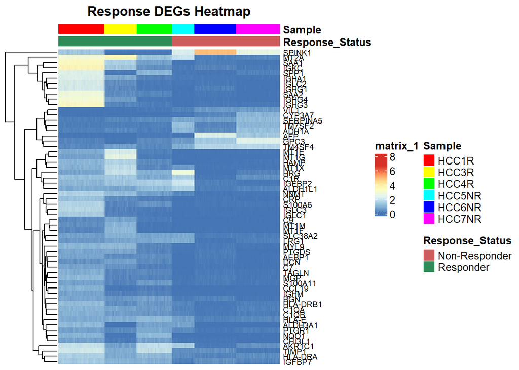

```r
top_degs<- rbind (response_degs %>%
  filter(avg_log2FC > 0, p_val_adj < 0.05) %>%
  arrange(p_val_adj) %>%
  head(50) %>%
  dplyr::select(-direction)

,  response_degs %>%
  filter(avg_log2FC < 0, p_val_adj < 0.05) %>%
 arrange(p_val_adj) %>%
  head(10) %>%
  dplyr::select(-direction)
)


# Extract expression matrix
expr_matrix <- as.matrix(GetAssayData(
  spatial.integrated.dctf
  , assay = "SCT"    # or "Spatial"
  , slot = "data"    # normalized data
))[top_degs$gene, ]

# Create annotation dataframe for columns (cells)
annotation_col <- data.frame(
  Response_Status = spatial.integrated.dctf$response
  , Sample = spatial.integrated.dctf$orig.ident
)
rownames(annotation_col) <- colnames(expr_matrix)

# Create annotation colors
annotation_colors <- list(
  Response_Status = c("Responder" = "#2E8B57", "Non-Responder" = "#CD5C5C"),
  Sample = rainbow(length(unique(spatial.integrated$orig.ident)))
)
names(annotation_colors$Sample) <- unique(spatial.integrated.dctf$orig.ident)

# Create pheatmap
pheatmap(
  as.matrix(expr_matrix)
  , annotation_col = annotation_col
  , annotation_colors = annotation_colors
  , cluster_rows = T
  , cluster_cols = F
  , show_colnames = FALSE            # Don't show cell names
  , show_rownames = TRUE             # Show gene names
  , fontsize_row = 8
  , fontsize_col = 6
  , border_color = NA
  , main = "Response DEGs Heatmap"
)
```